# Spatial Population Dynamics of Mosquitoes

Hector M Sanchez C, Sean Wu, …, David Smith

2/6/2020

$\uparrow$ Library || Mosquito | MBDETES

## Basic MBDETES

The variables in MBDETES equations represent the density of mosquitoes that are in each behavioral state, and the parameters describe state transition probabilities and associated waiting times. Let a variable name denote the population density of mosquitoes in each state, where the variable names in MBDETES matches the code letter for the behavioral states and the postprandial resting period in MBITES: blood feeding (B), egg laying (O), searching for blood (F), searching for habitats (L), and post-prandial resting (R), for each site. Let $P_{XY}$ denote the proportion of mosquitoes transitioning from state $X$ to $Y$ after one bout, $\gamma_X$ the rate mosquitoes transition from state $X$ to another state, and let $\Lambda_F(t)$ and $\Lambda_B(t)$ denote the rates of mosquitoes emerging end entering into F and B states, respectively:

$$\begin{equation}\begin{array}{rl}
\frac{dF}{dt} =& \Lambda_F(t)
+ \gamma_B P_{BF} B
+ \gamma_O P_{OF} O
+ \gamma_R P_{RF} R
- \gamma_F (1-P_{FF}) F \\
%
&\\
\frac{dB}{dt}=& \Lambda_B(t)
+ \gamma_F P_{FB} F
+ \gamma_R P_{RB} R
+ \gamma_O P_{OB} O
- \gamma_B (1-P_{BB}) B \\
%
&\\
\frac{dR}{dt} =&
\gamma_B P_{BR} B
- \gamma_R R\\
%
&\\
\frac{dL}{dt} =&
\gamma_R P_{RL} R
+ \gamma_O P_{OL} O
- \gamma_L (1-P_{LL}) L
\\
%
&\\
\frac{dO}{dt} =&
\gamma_R P_{RO} R
+ \gamma_L P_{LO} L
- \gamma_O(1-P_{OO}) O
%
\label{eqn::MBDETES}
\end{array}\end{equation}$$

This function (written for `deSolve`) returns the derivatives:

```r
mbdetesODE = function(t,y,p){with(as.list(c(y,p)),{
  dFdt = lF + gB*pBF*B + gO*pOF*O + gR*pRF*R - gF*(1-pFF)*F
  dBdt = lB + gF*pFB*F + gR*pRB*R + gO*pOB*O - gB*(1-pBB)*B
  dRdt = gB*pBR*B - gR*R
  dLdt = gR*pRL*R + gO*pOL*O - gL*(1-pLL)*L
  dOdt = gR*pRO*R + gL*pLO*L - gO*(1-pOO)*O
  list(c(dFdt,dBdt,dRdt,dLdt,dOdt))
})}
```

A constructor for the parameters.

```r
mbdetesMakeParameters = function(
  lF=1, lB=2,
  gF = 2, gB=2, gR = 1, gL = 2, gO = 2,
  pFF = .1, pFB = .8,
  pBF = .2, pBR = .4, pBB = .4,
  pRF = 0.02, pRB = 0.02, pRL = 0.45, pRO = 0.45,
  pLL = .4, pLO = .4,
  pOF = .1, pOB = .1, pOL = .2, pOO = .4){
  c(lF=lF, lB=lB,
       gF=gF, gB=gB, gR=gR, gL=gL, gO=gO,
       pFF=pFF, pFB=pFB,
       pBF=pBF, pBB=pBB, pBR=pBR,
       pRF=pRF, pRB=pRB, pRL=pRL, pRO=pRO,
       pLL=pLL, pLO=pLO,
       pOF=pOF, pOB=pOB, pOL=pOL, pOO=pOO)
}
mbdetesMakeParameters()
```

```
##   lF   lB   gF   gB   gR   gL   gO  pFF  pFB  pBF  pBB  pBR  pRF  pRB  pRL  pRO
## 1.00 2.00 2.00 2.00 1.00 2.00 2.00 0.10 0.80 0.20 0.40 0.40 0.02 0.02 0.45 0.45
##  pLL  pLO  pOF  pOB  pOL  pOO
## 0.40 0.40 0.10 0.10 0.20 0.40
```

```r
mbdetesMakeInits = function(F=0,B=0,R=0,L=0,O=0){
  c(F=F,B=B,R=R,L=L,O=O)
}
mbdetesMakeInits()
```

```
## F B R L O
## 0 0 0 0 0
```

```r
require(deSolve)
```

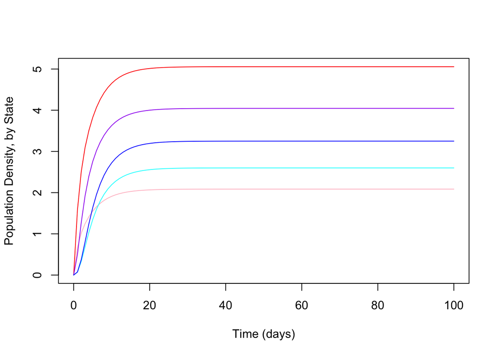

```r
mbdetesSolve = function(inits, params, tt=0:100){
  data.frame(ode(inits,tt,mbdetesODE,params))
}
inits=mbdetesMakeInits()
params = mbdetesMakeParameters()
x = mbdetesSolve(inits, params)

plot(x$time, x$F, type = "l", ylim = range(x$B, x$R, x$L, x$O, x$F), col = "pink", xlab = "Time (days)", ylab = "Population Density, by State")
lines(x$time, x$B, col = "red")
lines(x$time, x$R, col = "purple")
lines(x$time, x$L, col = "cyan")
lines(x$time, x$O, col = "blue")
```

## Spatial MBDETES (5 State)

Notation generally follows MBITES, but now we let $i$ index a set of haunts. All of the transition probabilities are haunt-dependent, so indexed by $i$. The major change is that mosquitoes move while searching, which is in states $F$ and $L$:

- Let $\theta_{j,i,F}$ and $\theta_{j,i,L}$ denote the probability of moving from $j$ to $i$ for blood and habitat searching, respectively.
- By assumption, emerging mosquitoes seek a blood meal upon emergence, if bloodmeal hosts are present. If no hosts are present, then this will be reflected in the transition probabilities at site $i$ and the mosquito will initialize a search.

$$\begin{equation}\begin{array}{rl}
\frac{dF_i}{dt} =& \sum_j \theta_{j,i,F} \gamma_{F,j} P_{FF,j} F_j
+ \gamma_{B,i} P_{BF,i} B_i
+ \gamma_{O,i} P_{OF,i} O_i
+ \gamma_{R,i} P_{RF,i} R_i
- \gamma_{F,i} P_{FF,i} F_i \\
%
&\\
\frac{dB_i}{dt}=& \sum_j \alpha_{i,j} L_{i,j}
+ \sum_j \theta_{j,i,F} \gamma_{F,j} P_{FB,j} F_j
+ \gamma_{R,i} P_{RB,i} R_i
+ \gamma_{O,i} P_{OB,i} O_i
- \gamma_{B,i} (1-P_{BB,i}) B_i \\
%
&\\
\frac{dR_i}{dt} =&
\gamma_{B,i} P_{BR,i} B_i
- \gamma_{R,i} R_i\\
%
&\\
\frac{dL_i}{dt} =&
\sum_j \theta_{j,i,L} \gamma_{L,j} P_{LL,j} L_j
+\gamma_{R,i} P_{RL,i} R_i
+\gamma_{O,i} P_{OL,i} O_i
-\gamma_{L,i} P_{LL,i} L_i
\\
%
&\\
\frac{dO_i}{dt} =&
\gamma_{R,i} P_{RO,i} R_i
+ \sum_j \theta_{j,i,L} \gamma_{L,j} P_{LO,j} L_j
- \gamma_{O,i}(1-P_{OO,i}) O_i
%
\label{eqn::MBDETES_spatial}
\end{array}\end{equation}$$

## Spatial MBDETES (3 State)

Notation generally follows MBITES, but now we let $i$ index a set of haunts. All of the transition probabilities are haunt-dependent, so indexed by $i$. The major change is that mosquitoes move while searching, which is in states $F$ and $L$:

- Let $\theta_{j,i,F}$ and $\theta_{j,i,L}$ denote the probability of moving from $j$ to $i$ for blood and habitat searching, respectively.
- By assumption, emerging mosquitoes seek a blood meal upon emergence, if bloodmeal hosts are present. If no hosts are present, then this will be reflected in the transition probabilities at site $i$ and the mosquito will initialize a search.

$$\begin{equation}\begin{array}{rl}
\frac{dB}{dt}= &
\Lambda
+ \nu Q
- \Omega_f B
- f B \\
%
&\\
\frac{dR}{dt} =&
f B
- (\gamma + g) R\\
%
&\\
\frac{dQ}{dt} =& \gamma R
- \Omega_\nu Q
- \nu Q
\\
%
\label{eqn::MBDETES3}
\end{array}\end{equation}$$

```r
BRQ_ode = function(t,y,p){with(as.list(c(y,p)),{
  dB = Lambda + nu*Q - g*B - f*B
  dR = f*B - (gamma + g)*R
  dQ = gamma*R - (g+nu)*Q
  list(c(dB, dR, dQ))
})}
```

```r
makePar_BRQ  = function(
  nPatch = 3,
  Lambda = 1,
  nu = 1.5, g=1/10, f=1.5, gamma = 1){
  list(Lambda=Lambda, nu=nu, g=g, f=f, gamma=gamma)
}
makePar_BRQ()
```

```
## $Lambda
## [1] 1
##
## $nu
## [1] 1.5
##
## $g
## [1] 0.1
##
## $f
## [1] 1.5
##
## $gamma
## [1] 1
```

```r
makeInits_BRQ = function(B=0, R=0, Q=0){
  c(B=B, R=R, Q=Q)
}
makeInits_BRQ()
```

```
## B R Q
## 0 0 0
```

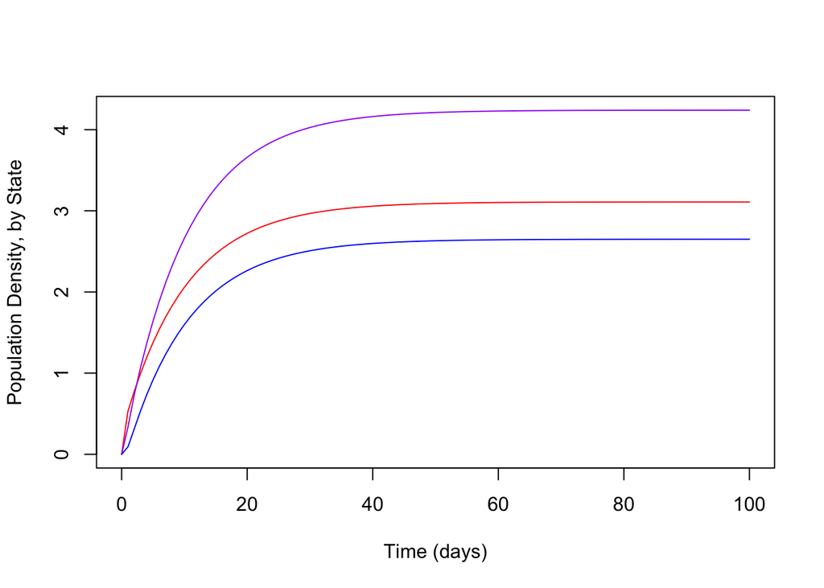

```r
require(deSolve)
BRQsolve = function(inits, params, tt=0:100){
  data.frame(ode(inits,tt,BRQ_ode,params))
}
inits = makeInits_BRQ()
params = makePar_BRQ()
x = BRQsolve(inits, params)

plot(x$time, x$B, type = "n", ylim = with(x,range(B, R, Q)), col = "pink", xlab = "Time (days)", ylab = "Population Density, by State")
lines(x$time, x$B, col = "red")
lines(x$time, x$R, col = "purple")
lines(x$time, x$Q, col = "blue")
```

## Spatial MBDETES (3 State) + Infection

$$\begin{equation}\begin{array}{rl}
\frac{dB_u}{dt}= &
\Lambda
+ \nu Q_u
- \Omega_f B_u
- f B_u \\
%
&\\
\frac{dR_u}{dt} =&
f(1-q\kappa) B_u
- (\gamma + g) R_u\\
%
&\\
%
\frac{dQ_u}{dt} =& \gamma R_u
- \Omega_\nu Q_u
- \nu Q_u
\\
%
&\\ \hline
&\\
%
\frac{dB_y}{dt}= &
\nu Q_y
- \Omega_f B_y
- f B_y \\
%
&\\
\frac{dR_y}{dt} =&
fq\kappa B_u + f B_y
- (\gamma + g) R_y\\
%
&\\
\frac{dQ_y}{dt} =& \gamma R_y
- \Omega_\nu Q_y
- \nu Q_y
\\
%
&\\ \hline
&\\
%
\frac{dB_z}{dt}= & \Theta_B +
\nu Q_z
- \Omega_f B_z
- f B_z \\
%
&\\
\frac{dR_z}{dt} =& \Theta_R +
f B_z
- (\gamma + g) R_z\\
%
&\\
\frac{dQ_z}{dt} =& \Theta_Q +
\gamma R_z
- \Omega_\nu Q_z
%
\label{eqn::MB_yDETES3yz}
\end{array}\end{equation}$$

The $\Theta$ terms represent a mosquitoes that became infected $t-\tau$ time units ago (*i.e.* $fq\kappa B_u (t-\tau)$) but who then survived the ensuing $\tau$ time units, meanwhile transitioning among stages. Try this:

$$\begin{equation}\begin{array}{rl}
\frac{d\Theta_B}{dt}= & B_y - B_y(t-\tau)\\
%
&\\
\frac{d\Theta_R}{dt} =& R_y - R_y(t-\tau)\\
%
&\\
\frac{d\Theta_Q}{dt} =& Q_y - Q_y(t-\tau)
\label{eqn::Theta}
\end{array}\end{equation}$$

```r
malariaBRQ_ode = function(t,y,p){with(as.list(c(y,p)),{
  dBu = Lambda + nu*Qu - g*Bu - f*Bu
  dRu = f*(1-q*kappa)*Bu - (gamma + g)*Ru
  dQu = gamma*Ru - (g+nu)*Qu
  dBy = nu*Qy - g*By - f*By
  dRy = f*q*kappa*Bu + f*By - (gamma + g)*Ry
  dQy = gamma*Ry - (g+nu)*Qy
  dBz = nu*Qz - g*Bz - f*Bz
  dRz = f*Bz - (gamma + g)*Rz
  dQz = gamma*Rz - (g+nu)*Qz
  list(c(dBu, dRu, dQu, dBy, dRy, dQy, dBz, dRz, dQz))
})}
```

```r
makePar_malBRQ  = function(
  nPatch = 3,
  Lambda = 1,
  nu = 1.5, g=1/10, f=1.5, gamma = 1, q=.95, kappa=0.1){
  list(Lambda=Lambda, nu=nu, g=g, f=f, gamma=gamma, q=q, kappa=kappa)
}
makePar_malBRQ()
```

```
## $Lambda
## [1] 1
##
## $nu
## [1] 1.5
##
## $g
## [1] 0.1
##
## $f
## [1] 1.5
##
## $gamma
## [1] 1
##
## $q
## [1] 0.95
##
## $kappa
## [1] 0.1
```

```r
makeInits_malBRQ = function(B=0, R=0, Q=0){
  c(Bu=B, Ru=R, Qu=Q,
    By=0, Ry=0, Qy=0,
    Bz=0, Rz=0, Qz=0)
}
makeInits_malBRQ()
```

```
## Bu Ru Qu By Ry Qy Bz Rz Qz
##  0  0  0  0  0  0  0  0  0
```

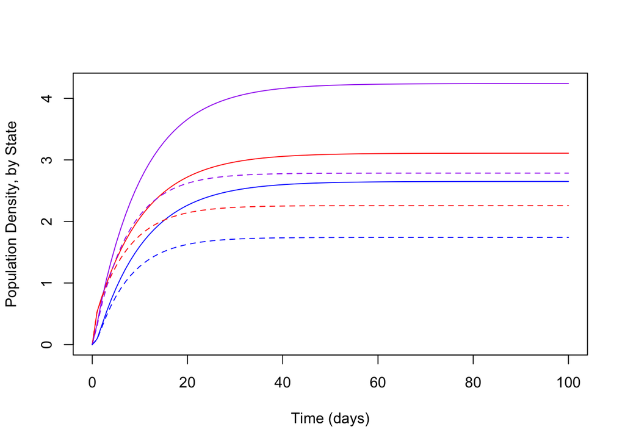

```r
require(deSolve)
malBRQsolve = function(inits, params, tt=0:100){
  data.frame(ode(inits,tt,malariaBRQ_ode,params))
}
inits = makeInits_malBRQ()
params = makePar_malBRQ()
x = malBRQsolve(inits, params)

plot(x$time, x$Bu, type = "n", ylim = with(x,range(Bu+By+Bz, Ru+Ry+Rz, Qu+Qy+Qz)), col = "pink", xlab = "Time (days)", ylab = "Population Density, by State")
lines(x$time, with(x,Bu+By+Bz), col = "red")
lines(x$time, with(x,Ru+Ry+Rz), col = "purple")
lines(x$time, with(x,Qu+Qy+Qz), col = "blue")
lines(x$time, x$Bu, col = "red", lty=2)
lines(x$time, x$Ru, col = "purple", lty=2)
lines(x$time, x$Qu, col = "blue", lty=2)
```

## Spatial MB_uDETES + Sugar

Notation generally follows MBITES, but now we let $i$ index a set of haunts. All of the transition probabilities are haunt-dependent, so indexed by $i$. The major change is that mosquitoes move while searching, which is in states $F$ and $L$:

- Let $\theta_{j,i,F}$ and $\theta_{j,i,L}$ denote the probability of moving from $j$ to $i$ for blood and habitat searching, respectively.
- By assumption, emerging mosquitoes seek a blood meal upon emergence, if bloodmeal hosts are present. If no hosts are present, then this will be reflected in the transition probabilities at site $i$ and the mosquito will initialize a search.

$$\begin{equation}\begin{array}{rl}
\frac{dB}{dt}= &
\Lambda
+ \sigma S
- \delta_B B
- \Omega_B B
- f B \\
%
&\\
\frac{dR}{dt} =&
f B
- (\gamma + g) R\\
%
&\\
\frac{dQ}{dt} =& \gamma R
- \Omega_Q Q
- (\nu + \delta_Q) Q
\\ \\
\frac{dS}{dt} =& (\nu + \delta_Q) Q + \delta_B B
- \Omega_S S
- \sigma S
%
\label{eqn::MBDETES3S}
\end{array}\end{equation}$$